# ChIPseq analysis of WT-73A and OE-73A

Last update: 11 October, 2017

# 1 Reads pre-processing

## 1.1 Quality control

Before alignment, quality control is required to check the quality of sequencing libraries including adaptor contaminations, duplication levels, and low-quality bases.

```r
./FastQC/fastqc \
        WT1_73A_S34_L006_R1_001.fastq.gz \
        WT1_IgG_S38_L006_R1_001.fastq.gz \
        WT1_In_S30_L006_R1_001.fastq.gz \
        WT2_73A_S35_L006_R1_001.fastq.gz \
        WT2_IgG_S39_L006_R1_001.fastq.gz \
        WT2_In_S31_L006_R1_001.fastq.gz \
        OE1_73A_S36_L006_R1_001.fastq.gz \
        OE1_IgG_S40_L006_R1_001.fastq.gz \
        OE1_In_S32_L006_R1_001.fastq.gz \
        OE2_73A_S37_L006_R1_001.fastq.gz \
        OE2_IgG_S41_L006_R1_001.fastq.gz \
        OE2_In_S33_L006_R1_001.fastq.gz
```

[QC report for WT1_73A](https://drive.google.com/open?id=0BzMGROMQpUH-YWcwaXJIc1VNclU)  
[QC report for WT1_IgG](https://drive.google.com/open?id=0BzMGROMQpUH-bzBCQ2Eya0pzV1k)  
[QC report for WT1_In](https://drive.google.com/open?id=0BzMGROMQpUH-VlpkcUhqSkxlTTA)  
[QC report for WT2_73A](https://drive.google.com/open?id=0BzMGROMQpUH-MnVkOHFudC0wemc)  
[QC report for WT2_IgG](https://drive.google.com/open?id=0BzMGROMQpUH-cVpCZllCV2FVZzQ)  
[QC report for WT2_In](https://drive.google.com/open?id=0BzMGROMQpUH-Q1JicXY5NGQ3R0k)  
[QC report for OE1_73A](https://drive.google.com/open?id=0BzMGROMQpUH-VG5vNGZVeWpNbms)  
[QC report for OE1_IgG](https://drive.google.com/open?id=0BzMGROMQpUH-SHdSTlE3R2YtMzQ)  
[QC report for OE1_In](https://drive.google.com/open?id=0BzMGROMQpUH-T1kydHR3Q2M0Mms)  
[QC report for OE2_73A](https://drive.google.com/open?id=0BzMGROMQpUH-dFRXNV9PN1o5LU0)  
[QC report for OE2_IgG](https://drive.google.com/open?id=0BzMGROMQpUH-ZzVkanE2eXR6dEk)  
[QC report for OE2_In](https://drive.google.com/open?id=0BzMGROMQpUH-WWFQRE5ibFhhSkE)

## 1.2 Trim low-quality reads and remove adaptor sequences

```r
java -jar $Trimmomatic/trimmomatic-0.36.jar SE \
        -threads 8 \
        -phred33 \
        -trimlog trim.log \
        $FILE \
        $SAMPLE.trimmed.fastq.gz \
        ILLUMINACLIP:$adaptor:2:40:15 \
        LEADING:0 \
        TRAILING:0 \
        SLIDINGWINDOW:4:15 \
        MINLEN:50
```

# 2 Alignment

## 2.1 BWA alignment

```r
bwa mem -t $CPU -v 1 -M $genome $FILE > $SAMPLE.sam
```

## 2.2 Sort .bam files and remove PCR duplications

```r
samtools sort -@ $CPU -T $SAMPLE.ALIGNtmp -O bam -o $SAMPLE.sorted.bam $SAMPLE.sam

java -Xmx48g -jar $Picard MarkDuplicates \
      ASSUME_SORTED=TRUE \
      REMOVE_DUPLICATES=TRUE \
      VALIDATION_STRINGENCY=LENIENT \
      INPUT=$SAMPLE.sorted.bam \
      OUTPUT=$SAMPLE.sorted.nodup.bam \
      METRICS_FILE=$SAMPLE.nodup.metrics


samtools flagstat $SAMPLE.sorted.nodup.bam > $SAMPLE.sorted.nodup.bam.flagstat
samtools index $SAMPLE.sorted.nodup.bam
```

# 3 Peak calling by SICER

## 3.1 Convert .bam to .bed format and merge replicates

```r
bamToBed -i OE1_73A_S36_L006_R1_001.trimmed.sorted.nodup.bam > OE1_73A_S36_L006_R1_001.trimmed.sorted.nodup.bed
bamToBed -i OE1_IgG_S40_L006_R1_001.trimmed.sorted.nodup.bam > OE1_IgG_S40_L006_R1_001.trimmed.sorted.nodup.bed
bamToBed -i OE1_In_S32_L006_R1_001.trimmed.sorted.nodup.bam > OE1_In_S32_L006_R1_001.trimmed.sorted.nodup.bed
bamToBed -i OE2_73A_S37_L006_R1_001.trimmed.sorted.nodup.bam > OE2_73A_S37_L006_R1_001.trimmed.sorted.nodup.bed
bamToBed -i OE2_IgG_S41_L006_R1_001.trimmed.sorted.nodup.bam > OE2_IgG_S41_L006_R1_001.trimmed.sorted.nodup.bed
bamToBed -i OE2_In_S33_L006_R1_001.trimmed.sorted.nodup.bam > OE2_In_S33_L006_R1_001.trimmed.sorted.nodup.bed
bamToBed -i WT1_73A_S34_L006_R1_001.trimmed.sorted.nodup.bam > WT1_73A_S34_L006_R1_001.trimmed.sorted.nodup.bed
bamToBed -i WT1_IgG_S38_L006_R1_001.trimmed.sorted.nodup.bam > WT1_IgG_S38_L006_R1_001.trimmed.sorted.nodup.bed
bamToBed -i WT1_In_S30_L006_R1_001.trimmed.sorted.nodup.bam > WT1_In_S30_L006_R1_001.trimmed.sorted.nodup.bed
bamToBed -i WT2_73A_S35_L006_R1_001.trimmed.sorted.nodup.bam > WT2_73A_S35_L006_R1_001.trimmed.sorted.nodup.bed
bamToBed -i WT2_IgG_S39_L006_R1_001.trimmed.sorted.nodup.bam > WT2_IgG_S39_L006_R1_001.trimmed.sorted.nodup.bed
bamToBed -i WT2_In_S31_L006_R1_001.trimmed.sorted.nodup.bam > WT2_In_S31_L006_R1_001.trimmed.sorted.nodup.bed


cat OE1_73A_S36_L006_R1_001.trimmed.sorted.nodup.bed OE2_73A_S37_L006_R1_001.trimmed.sorted.nodup.bed > OE_73A.bed
cat OE1_IgG_S40_L006_R1_001.trimmed.sorted.nodup.bed OE2_IgG_S41_L006_R1_001.trimmed.sorted.nodup.bed > OE_IgG.bed
cat OE1_In_S32_L006_R1_001.trimmed.sorted.nodup.bed OE2_In_S33_L006_R1_001.trimmed.sorted.nodup.bed > OE_In.bed

cat WT1_73A_S34_L006_R1_001.trimmed.sorted.nodup.bed WT2_73A_S35_L006_R1_001.trimmed.sorted.nodup.bed > WT_73A.bed
cat WT1_IgG_S38_L006_R1_001.trimmed.sorted.nodup.bed WT2_IgG_S39_L006_R1_001.trimmed.sorted.nodup.bed > WT_IgG.bed
cat WT1_In_S30_L006_R1_001.trimmed.sorted.nodup.bed WT2_In_S31_L006_R1_001.trimmed.sorted.nodup.bed > WT_In.bed
```

## 3.2 Peak calling

```r
sh $SICER/SICER.sh . WT_73A.bed WT_In_chr.bed . tair10 1 200 150 0.8 600 1e-2
sh $SICER/SICER.sh . WT_73A.bed WT_IgG_chr.bed . tair10 1 200 150 0.8 600 1e-2
sh $SICER/SICER.sh . OE_73A.bed OE_In_chr.bed . tair10 1 200 150 0.8 600 1e-2
sh $SICER/SICER.sh . OE_73A.bed OE_IgG_chr.bed . tair10 1 200 150 0.8 600 1e-2
```

## 3.3 Examples of obvious peaks

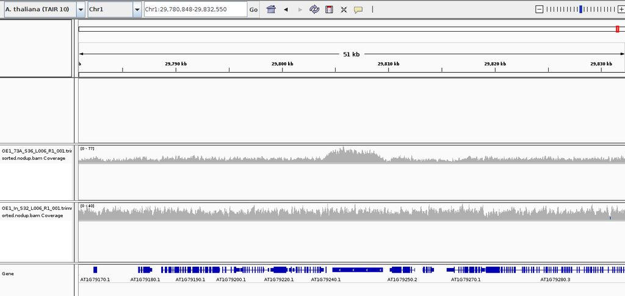

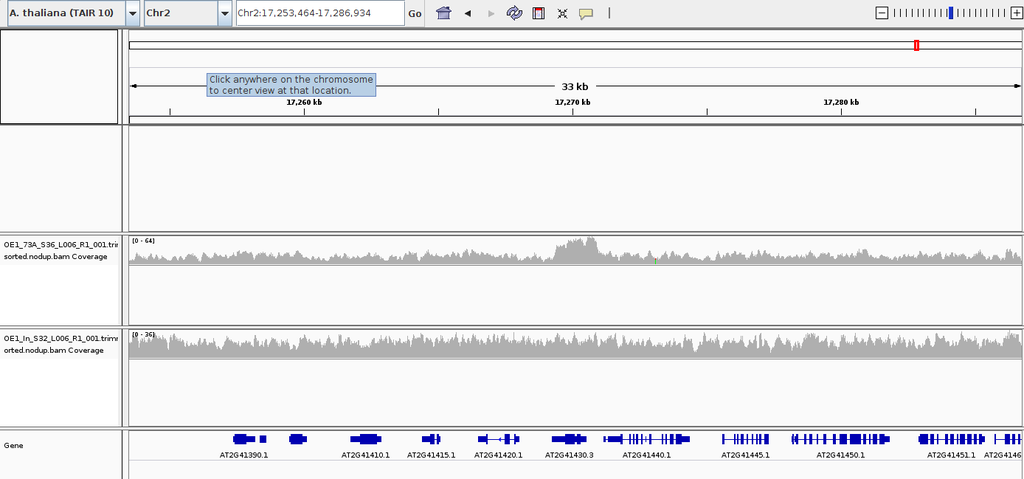

## 3.4 Peak annotation

### 3.4.1 Coverage plot of peak regions in WT-73A and OE-73A

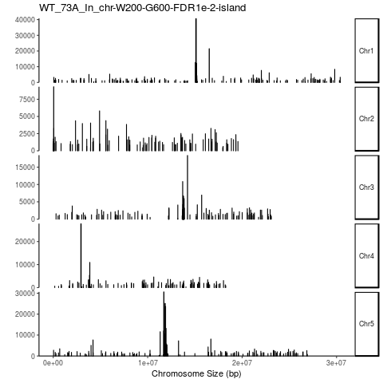

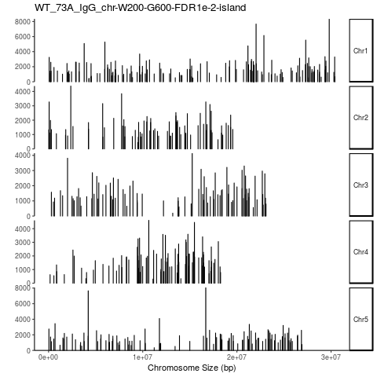

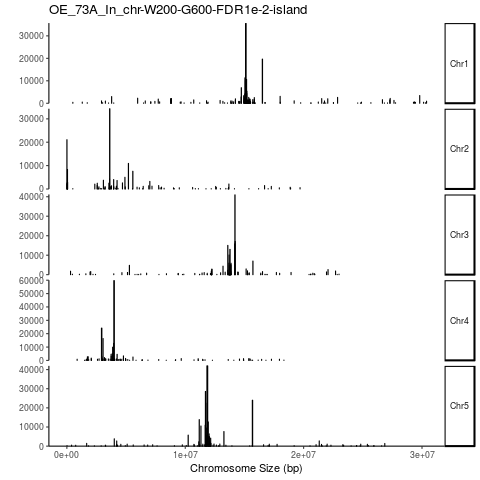

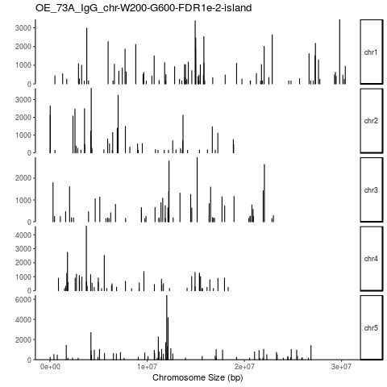

### 3.4.2 ChIPseeker annotation tables

[ChiPseeker.WT_73A_In_chr-W200-G600-FDR1e-2-island.txt](https://drive.google.com/open?id=0BzMGROMQpUH-ZUpSZ2Z1bDBZLUU)  
[ChiPseeker.WT_73A_IgG_chr-W200-G600-FDR1e-2-island.txt](https://drive.google.com/open?id=0BzMGROMQpUH-YzU1eHE5cUotOGc)  
[ChiPseeker.OE_73A_In_chr-W200-G600-FDR1e-2-island.txt](https://drive.google.com/open?id=0BzMGROMQpUH-aldROHBoUGtIams)  
[ChiPseeker.OE_73A_IgG_chr-W200-G600-FDR1e-2-island.txt](https://drive.google.com/open?id=0BzMGROMQpUH-QUVVWTdpTFlscjA)

### 3.4.3 Distribution of peaks

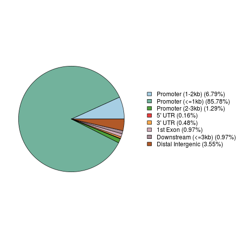

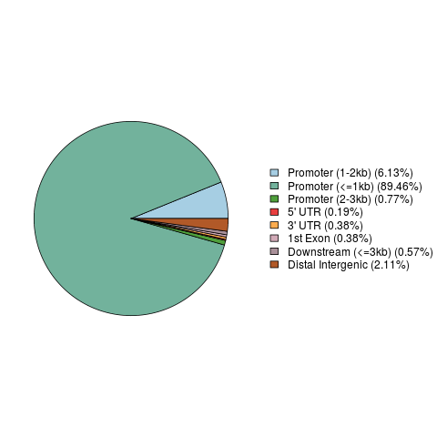

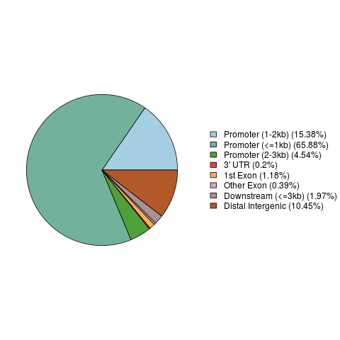

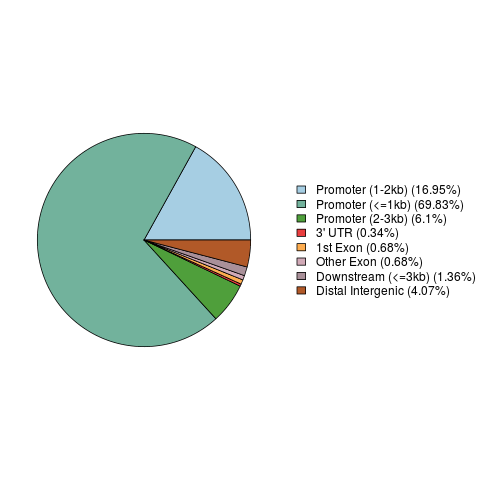